# Lab 1

Jimmy, Gabrielle, and Zev

2025-06-25

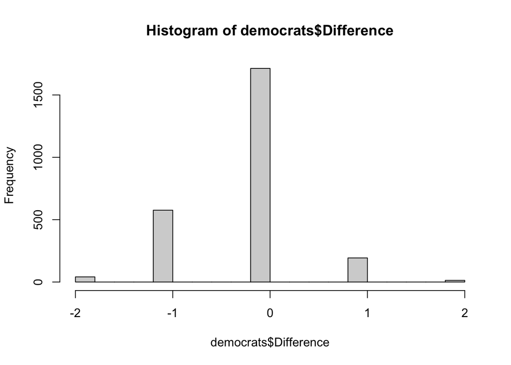

```
## [1] -0.1731073
```

```
## [1] 0
```

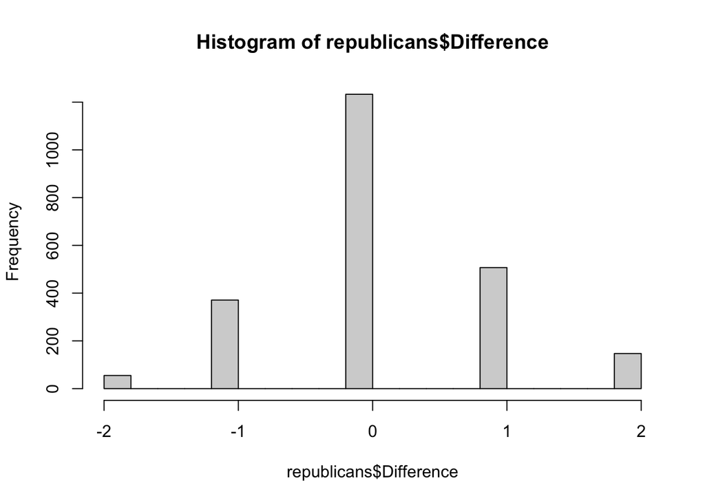

```
## [1] 0.1383485
```

```
## [1] 0
```

```
##
##  Wilcoxon signed rank test with continuity correction
##
## data:  democrats$public_schools and democrats$social_security
## V = 84660, p-value < 2.2e-16
## alternative hypothesis: true location shift is less than 0
```

```
##
##  Wilcoxon signed rank test with continuity correction
##
## data:  republicans$public_schools and republicans$social_security
## V = 366813, p-value = 1.881e-15
## alternative hypothesis: true location shift is greater than 0
```

#Alternative hypothesis is public school < social security

```
##
##  Exact binomial test
##
## data:  sum(democrats$Difference < 0, na.rm = TRUE) and sum(democrats$Difference != 0, na.rm = TRUE)
## number of successes = 617, number of trials = 823, p-value < 2.2e-16
## alternative hypothesis: true probability of success is greater than 0.5
## 95 percent confidence interval:
##  0.7236083 1.0000000
## sample estimates:
## probability of success
##              0.7496962
```

```
##
##  Exact binomial test
##
## data:  sum(republicans$Difference > 0, na.rm = TRUE) and sum(republicans$Difference != 0, na.rm = TRUE)
## number of successes = 654, number of trials = 1080, p-value = 2.065e-12
## alternative hypothesis: true probability of success is greater than 0.5
## 95 percent confidence interval:
##  0.5804387 1.0000000
## sample estimates:
## probability of success
##              0.6055556
```

# Introduction

We suspect that Democrats will favor increasing spending in public schools more than social security. Whereas Republicans will be the other way around. So we will set up two hypothesis test using the Wilcoxon Signed Rank test.

Test set up:

Let Xi = preference for **public school spending (**V241264)**, where:**

- 1 = Increased
- 2 = Kept the same
- 3 = Decreased

Let Yi = preference for **social security spending (**V241261)**,** with the same code as Xi

Let Di = Xi - Yi, with interpretation:

- -2 represents public schools =1 (Increase) **vs.** social security =3 (Decrease): extremely more support for schools
- -1 represents public schools =1 (Increase) **vs.** social security =2 (Same), **or** public schools =2 (Same) **vs.** social security =3 (Dec): more support for schools
- 0 represents public schools and social security coded the same: equal support (both Increase, both Same, or both Decrease)
- 1 represents public schools =2 (Same) **vs.** social security =1 (Increase), **or** public schools =3 (Dec) **vs.** social security =2 (Same): more support for Social Security
- 2 represents public schools =3 (Decrease) **vs.** social security =1 (Increase): extremely more support for Social Security

**Test 1:**

Null hypothesis (Ho): average Di | i in Democrats = 0

Alternative hypothesis (H1): average Di | i in Democrats < 0 , favoring public schools

**Test 2:**  
Null hypothesis (Ho): average Di | i in Republicans = 0

Alternative hypothesis (H1): average Di | i in Republicans > 0 , favoring social security